# KODUTÖÖ 2 Andmete ettevalmistamine, kirjeldamine ja visualiseerimine

MEM5270 Statistilised meetodid masinõppes

Autor

Hanna Liis Lillepalu

Kuupäev

6. oktoober 2026

**NoteEnne alustamist**

- Salvesta see fail ja andmefail `MEM5270_2026_Kodutoo_2_andmed.csv` samasse kausta.
- Renderdatud raport peab olema loetav ühe .html failina: ära muuda YAML-päises rida `embed-resources: true`.
- Kood peab töötama ilma Sinu sekkumiseta. Ära kasuta koodiplokkides `View()` (see avab akna ainult RStudios ja renderdamine katkeb veaga), `install.packages()` ega absoluutseid failiteid (`C:/Users/...`).
- Vastused kirjuta tavalise tekstina koodiploki juurde, mitte koodi sisse kommentaarina.

### Ülesanne 1. Andmete sisselugemine ja esmane kontroll

(a) Loe fail R-i sisse (`read.csv()`) ja kontrolli selle mõõtmeid (näiteks käsu `dim()` abil): andmestikus peab olema 29 591 rida ja 19 veergu. Mida teeb `read.csv()` valik `na.strings = c("", "NA")`?

```r
andmed <- read.csv("MEM5270_2026_Kodutoo_2_andmed.csv",
                   na.strings = c("", "NA"), encoding = "UTF-8")
dim(andmed)
```

```
[1] 29591    19
```

**#Vastus 1a:** Andmestikus on 29591 rida ja 19 veergu.Valik `na.strings = c(““,”NA”) määrab, et tühjad väärtused ja tekstina “NA”, tähendavad puuduvaid väärtusi.

(b) Uuri andmestikku `dplyr` teegi käsu (`glimpse()`) abil. Näete muuhulgas andmestiku tunnuste nimesid ja nende tüüpe. Andmetüüpide tundmine on R-i kasutamisel tähtis. Kirjuta lühidalt, mida selles andmestiku esindatud tüübid `int`, `dbl` ja `chr` tähendavad.

```r
dplyr::glimpse(andmed)
```

```
Rows: 29,591
Columns: 19
$ registrikood            <int> 10000018, 10000024, 10000165, 10000248, 100003…
$ nimi                    <chr> "Amserv Auto Osaühing", "osaühing \"Eesti Raam…
$ maakond                 <chr> "Harju maakond", "Harju maakond", "Ida-Viru ma…
$ sektor_taht             <chr> "G", "J", "G", "G", "N", "C", "C", "F", "G", "…
$ sektor                  <chr> "Hulgi- ja jaekaubandus", "Kirjastamine, ringh…
$ kategooria              <chr> "Suurettevõtja", "Mikroettevõtja", "Väikeettev…
$ esitatud_kpv            <chr> "2025-06-20", "2025-06-28", "2025-06-03", "202…
$ tootajad                <int> 238, 9, 35, 3, 18, 92, 4, 3, 29, 7, 260, 131, …
$ toojoukulud             <int> 11542617, 242011, 856116, 147927, 735798, 3871…
$ muugitulu               <int> 140298558, 862204, 4735051, 2007668, 1441441, …
$ varad                   <dbl> 32614511, 438172, 3408219, 1554834, 94392263, …
$ kaibevarad              <int> 16894065, 426336, 1940339, 1541736, 3482890, 2…
$ pohivarad               <dbl> 15720446, 11836, 1467880, 13098, 90909373, 955…
$ luhiajalised_kohustised <dbl> 17122430, 103871, 489739, 90400, 25286625, 259…
$ pikaajalised_kohustised <dbl> 1152985, 0, 152787, NA, NA, 3600000, NA, 16907…
$ omakapital              <dbl> 14339096, 334301, 2765693, 1464434, 69105638, …
$ kulum                   <dbl> 979381, NA, 79042, 7704, NA, 457942, 0, 9039, …
$ arikasum                <int> 2858793, 121270, 321444, 373537, -26031, 65311…
$ aruandeaasta_kasum      <int> 3532612, 136720, 227110, 411662, 7426519, 3931…
```

**#Vastus 1b**: `int` tähistab täisarvu, `dbl` arvulist väärtust, mis võib sisaldada komakohti, ning `chr` tekstilist väärtust.

(c) Teisenda `esitatud_kpv` kuupäevaks ning `maakond`, `sektor_taht`, `sektor` ja `kategooria` faktortunnusteks (nii nimetatakse R-is nn kategoriaalseid tunnuseid). Mõtle, mida ja kuidas kood teeb.

```r
andmed$esitatud_kpv <- as.Date(andmed$esitatud_kpv)
faktoriteks <- c("maakond", "sektor_taht", "sektor", "kategooria")
andmed[faktoriteks] <- lapply(andmed[faktoriteks], as.factor)
```

**#Vastus 1c**: Antud kood teisendab `esitatud_kpv` kuupäeva formaati (YMD). Tunnused `maakond`, jt., teisendatakse faktortunnusteks, mida kasutatakse kategoriaalsete tunnuste esitamiseks.

### Ülesanne 2. Puuduvad ja ekstreemsed väärtused

(a) Uuri andmestikku, näiteks käsu `summary()` abil. Mitu puuduvat väärtust (`NA` ehk *not available*) on igas tunnuses?

```r
summary(andmed)
```

```
  registrikood          nimi                         maakond
 Min.   :10000018   Length:29591       Harju maakond     :16198
 1st Qu.:10900384   Class :character   Tartu maakond     : 3557
 Median :12007728   Mode  :character   Pärnu maakond     : 1851
 Mean   :12474986                      Ida-Viru maakond  : 1678
 3rd Qu.:14203862                      Lääne-Viru maakond: 1100
 Max.   :16942218                      (Other)           : 5154
                                       NA's              :   53
  sektor_taht                                        sektor
 F      : 5389   Ehitus                                 : 5389
 G      : 5036   Hulgi- ja jaekaubandus                 : 5036
 C      : 3660   Töötlev tööstus                        : 3660
 N      : 2569   Kutse-, teadus- ja tehnikaalane tegevus: 2569
 H      : 2106   Veondus ja laondus                     : 2106
 (Other):10830   (Other)                                :10830
 NA's   :    1   NA's                                   :    1
                        kategooria     esitatud_kpv           tootajad
 Keskmise suurusega ettevõtja:  445   Min.   :2025-01-02   Min.   :   2.00
 Mikroettevõtja              :23002   1st Qu.:2025-05-31   1st Qu.:   2.00
 Suurettevõtja               :  108   Median :2025-06-26   Median :   4.00
 Väikeettevõtja              : 6036   Mean   :2025-06-17   Mean   :  10.84
                                      3rd Qu.:2025-06-30   3rd Qu.:   8.00
                                      Max.   :2026-08-31   Max.   :2906.00

  toojoukulud         muugitulu             varad             kaibevarad
 Min.   :   10004   Min.   :1.200e+01   Min.   :0.000e+00   Min.   :    -9106
 1st Qu.:   36360   1st Qu.:1.288e+05   1st Qu.:7.124e+04   1st Qu.:    38154
 Median :   76233   Median :3.168e+05   Median :2.215e+05   Median :   118102
 Mean   :  328750   Mean   :1.914e+06   Mean   :1.772e+06   Mean   :   777452
 3rd Qu.:  198898   3rd Qu.:9.173e+05   3rd Qu.:7.395e+05   3rd Qu.:   380237
 Max.   :98854013   Max.   :1.123e+09   Max.   :1.427e+09   Max.   :524813000
                                                            NA's   :1
   pohivarad         luhiajalised_kohustised pikaajalised_kohustised
 Min.   :0.000e+00   Min.   :        0       Min.   :        0
 1st Qu.:1.145e+04   1st Qu.:    15660       1st Qu.:        0
 Median :5.691e+04   Median :    48087       Median :    23305
 Mean   :1.074e+06   Mean   :   430297       Mean   :   468853
 3rd Qu.:2.860e+05   3rd Qu.:   163272       3rd Qu.:   114755
 Max.   :1.397e+09   Max.   :587549000       Max.   :434985000
 NA's   :2187        NA's   :111             NA's   :12874
   omakapital            kulum              arikasum
 Min.   :-18962283   Min.   :        0   Min.   :-73461000
 1st Qu.:    26472   1st Qu.:     2098   1st Qu.:    -2836
 Median :   113239   Median :     7787   Median :    10056
 Mean   :  1078691   Mean   :    79996   Mean   :   111464
 3rd Qu.:   420267   3rd Qu.:    27096   3rd Qu.:    58530
 Max.   :552535000   Max.   :198683000   Max.   :125503000
                     NA's   :4600
 aruandeaasta_kasum
 Min.   :-103699000
 1st Qu.:     -3580
 Median :      7452
 Mean   :     99422
 3rd Qu.:     50578
 Max.   : 124958000
```

**#Vastus 2a**: Puudulikke väärtusi esineb tunnustes, nagu `maakond`(53), `sektor_taht`(1), `sektor`(1), `kaibevarad`(1), `pohivarad`(2187), `luhiajalised_kohustised`(111), `pikaajalised_kohustised`(12874) ja `kulum`(4600).Ülejäänud tunnustes pole NA väärtusi.

(b) Otsusta iga puuduvate väärtustega tunnuse kohta, kas jätad `NA` alles, asendad nulliga või eemaldad need read andmestikust. Põhjenda lühidalt iga otsust ja tee otsustatud muudatused koodis ära.

Vihje: juhendi punkt 2 ütleb, mida puuduv väärtus bilansireal enamasti tähendab. Seda saab andmetest ka kontrollida – bilansis kehtib `varad` = `kaibevarad` + `pohivarad` ja `varad` = `luhiajalised_kohustised` + `pikaajalised_kohustised` + `omakapital`. Kas need võrdused kehtivad, kui puuduv väärtus lugeda nulliks?

```r
library(tidyverse)
andmed <- andmed %>%
  mutate(
    kaibevarad = replace_na(kaibevarad, 0),
    pohivarad = replace_na(pohivarad, 0),
    luhiajalised_kohustised = replace_na(luhiajalised_kohustised, 0),
    pikaajalised_kohustised = replace_na(pikaajalised_kohustised, 0)
  )
```

**#Vastus 2b:** Bilansi puuduvate väärtuste nulliks lugemist toetas kontroll, sest võrrand `varad = kaibevarad + pohivarad` kehtis kõigil juhtudel ning võrrandis `varad = luhiajalised_kohustised + pikaajalised_kohustised + omakapital` esines ainult 12 erandit. Seetõttu asendasin puuduvad väärtused tunnustes `kaibevarad`, `pohivarad`, `luhiajalised_kohustised` ja `pikaajalised_kohustised` nulliga. Tunnuse `kulum` puuduvad väärtused jätsin `NA`-ks. `maakond`, `sektor_taht` ja `sektor` puuduvad väärtused jätsin samuti `NA`-ks, sest nende väärtusi ei ole andmete põhjal usaldusväärselt võimalik määrata.

(c) Vaata tunnuste `tootajad`, `muugitulu`, `varad` ja `omakapital` miinimum- ja maksimumväärtusi ning suurima ja väikseima väärtusega ettevõtteid (nt `which.min()` / `which.max()` või `dplyr::slice_min()` / `slice_max()`). Kas leiad midagi üllatavat?

```r
andmed %>%
  slice_min(tootajad, n = 5) %>%
  select(nimi, tootajad)
```

| nimi | tootajad |
| --- | --- |
| osaühing "EVOLER" | 2 |
| osaühing SCANWOOD | 2 |
| OÜ Havera | 2 |
| Destein Osaühing | 2 |
| Osaühing MACULA | 2 |
| Osaühing Audiitoribüroo Revisor | 2 |
| osaühing ATRENDA | 2 |
| Osaühing Fraumel | 2 |
| OÜ KNJ-Transport | 2 |
| Osaühing Kiretec | 2 |

[output cut: 9497 more lines]

```r
andmed %>%
  slice_max(tootajad, n = 5) %>%
  select(nimi, tootajad)
```

| nimi | tootajad |
| --- | --- |
| Selver AS | 2906 |
| Rimi Eesti Food AS | 2588 |
| Aktsiaselts Ida-Tallinna Keskhaigla | 2258 |
| Aktsiaselts Tallinna Linnatransport | 2065 |
| Ericsson Eesti Aktsiaselts | 1796 |

```r
andmed %>%
  slice_min(muugitulu, n = 5, with_ties = FALSE) %>%
  select(nimi, muugitulu)
```

| nimi | muugitulu |
| --- | --- |
| OÜ Aladja Media Management | 12 |
| Osaühing ALELIS | 26 |
| Oleviku talu OÜ | 67 |
| Digiotouch OÜ | 100 |
| Sapere Aude OÜ | 106 |

```r
andmed %>%
  slice_max(muugitulu, n = 5, with_ties = FALSE) %>%
  select(nimi, muugitulu)
```

| nimi | muugitulu |
| --- | --- |
| Bolt Operations OÜ | 1122869000 |
| Selver AS | 620836000 |
| aktsiaselts Olerex | 551598456 |
| Enefit Industry OÜ | 490410000 |
| Rimi Eesti Food AS | 483047000 |

```r
andmed %>%

  slice_min(varad, n = 5, with_ties = FALSE) %>%
  select(nimi, varad)
```

| nimi | varad |
| --- | --- |
| OSAÜHING MOLINAR | 0 |
| osaühing DVIGATEL TEST | 0 |
| RASTINA OÜ | 0 |
| Ammar OÜ | 0 |
| JR stuudio OÜ | 4 |

```r
andmed %>%
  slice_max(varad, n = 5, with_ties = FALSE) %>%
  select(nimi, varad)
```

| nimi | varad |
| --- | --- |
| Elektrilevi OÜ | 1427404000 |
| Riigi Kinnisvara Aktsiaselts | 758230000 |
| Enefit Industry OÜ | 704906000 |
| Bolt Operations OÜ | 613744000 |
| P&E Capital OÜ | 511422627 |

```r
andmed %>%
  slice_min(omakapital, n = 5, with_ties = FALSE) %>%
  select(nimi, omakapital)
```

| nimi | omakapital |
| --- | --- |
| Baltania OÜ | -18962283 |
| Solaris Keskus OÜ | -12291585 |
| OÜ CRANFELD INVEST | -8512762 |
| Live88 Studios OÜ | -7909224 |
| Fibenol Imavere OÜ | -7628723 |

```r
andmed %>%
  slice_max(omakapital, n = 5, with_ties = FALSE) %>%
  select(nimi, omakapital)
```

| nimi | omakapital |
| --- | --- |
| Elektrilevi OÜ | 552535000 |
| Riigi Kinnisvara Aktsiaselts | 515664000 |
| P&E Capital OÜ | 510924123 |
| Elisa Eesti AS | 442624000 |
| AS Eesti Varude Keskus | 385229138 |

**#Vastus 2c**: Andmetes on väga suur erinevus ettevõtete suuruse vahel. Töötajate arv ulatub 2-st kuni 2906-ni ning müügitulu 12 eurost kuni 1 122 869 000 euroni. Varade väärtus ulatub 0 eurost kuni 1 427 404 000 euroni. Omakapital varieerub −18 962 283 eurost kuni 552 535 000 euroni.

Üllatav on väga väike müügitulu mõnel vähemalt kahe töötajaga ettevõttel ning see, et mõnel ettevõttel on varade väärtus 0. Samuti esineb väga suur negatiivne omakapital, näiteks Baltania OÜ-l (−18 962 283 €). See näitab, et andmestikus on väga erineva suurusega ettevõtteid ning ka ettevõtete endi esitatud andmetes võib esineda ebakõlasid.

### Ülesanne 3. Uute tunnuste loomine

(a) Loo järgmised tunnused:

- `toojoukulu_tootaja` = `toojoukulud` / `tootajad` ehk tööjõukulu töötaja kohta, eurot aastas;
- `log_toojoukulu_tootaja` ehk sama tunnuse naturaallogaritm;
- `muugitulu_tootaja` = `muugitulu` / `tootajad`;
- `log_muugitulu_tootaja` ehk sama tunnuse naturaallogaritm;
- `omakapitali_osakaal` = `omakapital` / `varad`;
- `kahjum` – TRUE, kui `aruandeaasta_kasum` on negatiivne;
- `suurusklass` – faktortunnus töötajate arvu alusel: „2–4“, „5–9“, „10–49“, „50+“.

```r
andmed <- andmed %>%
  mutate(
    toojoukulu_tootaja = toojoukulud / tootajad,
    log_toojoukulu_tootaja = log(toojoukulu_tootaja),
    muugitulu_tootaja = muugitulu / tootajad,
    log_muugitulu_tootaja = log(muugitulu_tootaja),
    omakapitali_osakaal = omakapital / varad,
    kahjum = aruandeaasta_kasum < 0,
    suurusklass = cut(
      tootajad,
      breaks = c(0, 4.99, 9.99, 49.99, Inf),
      labels = c("2–4", "5–9", "10–49", "50+")
    )
  )
```

(b) Vaata tuletatud tunnuste kokkuvõtet (`summary()`). Kui mõnes kohas tekkis `Inf`, `-Inf` või `NaN`, siis selgita välja, milline tehe ja millised ettevõtted need tekitavad, ja otsusta, mida nende ridadega teha.

```r
andmed %>%
  select(toojoukulu_tootaja, log_toojoukulu_tootaja,
         muugitulu_tootaja, log_muugitulu_tootaja,
         omakapitali_osakaal, kahjum, suurusklass) %>%
  summary()
```

```
 toojoukulu_tootaja log_toojoukulu_tootaja muugitulu_tootaja
 Min.   :  5002     Min.   : 8.518         Min.   :       4
 1st Qu.: 13406     1st Qu.: 9.503         1st Qu.:   40185
 Median : 19379     Median : 9.872         Median :   71472
 Mean   : 23342     Mean   : 9.897         Mean   :  171266
 3rd Qu.: 29004     3rd Qu.:10.275         3rd Qu.:  134083
 Max.   :199927     Max.   :12.206         Max.   :84073151

 log_muugitulu_tootaja omakapitali_osakaal   kahjum        suurusklass
 Min.   : 1.386        Min.   :  -Inf      Mode :logical   2–4  :17185
 1st Qu.:10.601        1st Qu.:0.3552      FALSE:20589     5–9  : 6319
 Median :11.177        Median :0.6289      TRUE :9002      10–49: 5227
 Mean   :11.241        Mean   :  -Inf                      50+  :  860
 3rd Qu.:11.806        3rd Qu.:0.8278
 Max.   :18.247        Max.   :1.0000
                       NA's   :3
```

```r
andmed %>%
  filter(is.na(omakapitali_osakaal) | is.infinite(omakapitali_osakaal)) %>%
  select(nimi, varad, omakapital, omakapitali_osakaal)
```

| nimi | varad | omakapital | omakapitali_osakaal |
| --- | --- | --- | --- |
| OSAÜHING MOLINAR | 0 | 0 | NaN |
| osaühing DVIGATEL TEST | 0 | 0 | NaN |
| RASTINA OÜ | 0 | 0 | NaN |
| Ammar OÜ | 0 | -10 | -Inf |

```r
andmed$omakapitali_osakaal[
  is.na(andmed$omakapitali_osakaal) |
    is.infinite(andmed$omakapitali_osakaal)
] <- NA
```

**#Vastus 3b:** Tuletatud tunnuste kokkuvõttest selgus, et `omakapitali_osakaal` tunnuses esines `NaN` ja `-Inf` väärtusi. Need tekkisid ettevõtetel, kelle varade väärtus oli 0, sest omakapitali osakaal arvutatakse valemiga `omakapital / varad`. Nulliga jagamisel ei saa saadud väärtust sisuliselt kasutada. Seetõttu asendasin `NaN` ja `-Inf` väärtused `NA`-ga. Teistes tuletatud tunnustes `Inf`, `-Inf` ega `NaN` väärtusi ei esinenud.

### Ülesanne 4. Kirjeldav statistika

(a) Loo kokkuvõttev tabel (n, keskmine, mediaan, standardhälve, miinimum, maksimum) tunnuste `tootajad`, `muugitulu`, `toojoukulu_tootaja`, `muugitulu_tootaja` ja `omakapitali_osakaal` jaoks. Tabel peab olema renderdatud raportis näha.

```r
tabel <- data.frame(
  tunnus = c(
    "tootajad",
    "muugitulu",
    "toojoukulu_tootaja",
    "muugitulu_tootaja",
    "omakapitali_osakaal"
  ),
  n = c(
    sum(!is.na(andmed$tootajad)),
    sum(!is.na(andmed$muugitulu)),
    sum(!is.na(andmed$toojoukulu_tootaja)),
    sum(!is.na(andmed$muugitulu_tootaja)),
    sum(!is.na(andmed$omakapitali_osakaal))
  ),
  keskmine = c(
    mean(andmed$tootajad, na.rm = TRUE),
    mean(andmed$muugitulu, na.rm = TRUE),
    mean(andmed$toojoukulu_tootaja, na.rm = TRUE),
    mean(andmed$muugitulu_tootaja, na.rm = TRUE),
    mean(andmed$omakapitali_osakaal, na.rm = TRUE)
  ),
  mediaan = c(
    median(andmed$tootajad, na.rm = TRUE),
    median(andmed$muugitulu, na.rm = TRUE),
    median(andmed$toojoukulu_tootaja, na.rm = TRUE),
    median(andmed$muugitulu_tootaja, na.rm = TRUE),
    median(andmed$omakapitali_osakaal, na.rm = TRUE)
  ),
  sd = c(
    sd(andmed$tootajad, na.rm = TRUE),
    sd(andmed$muugitulu, na.rm = TRUE),
    sd(andmed$toojoukulu_tootaja, na.rm = TRUE),
    sd(andmed$muugitulu_tootaja, na.rm = TRUE),
    sd(andmed$omakapitali_osakaal, na.rm = TRUE)
  ),
  min = c(
    min(andmed$tootajad, na.rm = TRUE),
    min(andmed$muugitulu, na.rm = TRUE),
    min(andmed$toojoukulu_tootaja, na.rm = TRUE),
    min(andmed$muugitulu_tootaja, na.rm = TRUE),
    min(andmed$omakapitali_osakaal, na.rm = TRUE)
  ),
  max = c(
    max(andmed$tootajad, na.rm = TRUE),
    max(andmed$muugitulu, na.rm = TRUE),
    max(andmed$toojoukulu_tootaja, na.rm = TRUE),
    max(andmed$muugitulu_tootaja, na.rm = TRUE),
    max(andmed$omakapitali_osakaal, na.rm = TRUE)
  )
)

knitr::kable(tabel)
```

| tunnus | n | keskmine | mediaan | sd | min | max |
| --- | --- | --- | --- | --- | --- | --- |
| tootajad | 29591 | 1.083566e+01 | 4.000000e+00 | 4.911288e+01 | 2.0 | 2906.0 |
| muugitulu | 29591 | 1.914160e+06 | 3.168070e+05 | 1.315426e+07 | 12.0 | 1122869000.0 |
| toojoukulu_tootaja | 29591 | 2.334227e+04 | 1.937925e+04 | 1.493102e+04 | 5002.0 | 199926.5 |
| muugitulu_tootaja | 29591 | 1.712659e+05 | 7.147200e+04 | 8.809761e+05 | 4.0 | 84073151.0 |
| omakapitali_osakaal | 29587 | 1.863816e-01 | 6.288753e-01 | 5.104440e+01 | -8765.9 | 1.0 |

(b) Loo sagedustabelid (arv ja osakaal) tunnustele `sektor`, `maakond` ja `kategooria`.

```r
sektor_tabel <- andmed %>%
  count(sektor) %>%
  mutate(osakaal = n / sum(n))

maakond_tabel <- andmed %>%
  count(maakond) %>%
  mutate(osakaal = n / sum(n))

kategooria_tabel <- andmed %>%
  count(kategooria) %>%
  mutate(osakaal = n / sum(n))

knitr::kable(sektor_tabel)
```

| sektor | n | osakaal |
| --- | --- | --- |
| Ehitus | 5389 | 0.1821162 |
| Energeetika | 93 | 0.0031428 |
| Haldus- ja abitegevused | 1561 | 0.0527525 |
| Haridus | 298 | 0.0100706 |
| Hulgi- ja jaekaubandus | 5036 | 0.1701869 |
| Kinnisvara | 1034 | 0.0349431 |
| Kirjastamine, ringhääling ja sisutootmine | 250 | 0.0084485 |
| Kunst, sport ja meelelahutus | 322 | 0.0108817 |
| Kutse-, teadus- ja tehnikaalane tegevus | 2569 | 0.0868169 |
| Majutus ja toitlustus | 1745 | 0.0589706 |
| Muud teenindavad tegevused | 1515 | 0.0511980 |
| Mäetööstus | 73 | 0.0024670 |
| Põllumajandus, metsamajandus ja kalapüük | 1459 | 0.0493055 |
| Telekommunikatsioon ja IT | 1233 | 0.0416681 |
| Tervishoid ja sotsiaalhoolekanne | 1082 | 0.0365652 |
| Töötlev tööstus | 3660 | 0.1236863 |
| Veevarustus ja jäätmekäitlus | 165 | 0.0055760 |
| Veondus ja laondus | 2106 | 0.0711703 |
| NA | 1 | 0.0000338 |

```r
knitr::kable(maakond_tabel)
```

| maakond | n | osakaal |
| --- | --- | --- |
| Harju maakond | 16198 | 0.5473962 |
| Hiiu maakond | 185 | 0.0062519 |
| Ida-Viru maakond | 1678 | 0.0567064 |
| Jõgeva maakond | 505 | 0.0170660 |
| Järva maakond | 468 | 0.0158156 |
| Lääne-Viru maakond | 1100 | 0.0371735 |
| Lääne maakond | 385 | 0.0130107 |
| Põlva maakond | 428 | 0.0144639 |
| Pärnu maakond | 1851 | 0.0625528 |
| Rapla maakond | 661 | 0.0223379 |
| Saare maakond | 660 | 0.0223041 |
| Tartu maakond | 3557 | 0.1202055 |
| Valga maakond | 423 | 0.0142949 |
| Viljandi maakond | 838 | 0.0283194 |
| Võru maakond | 601 | 0.0203102 |
| NA | 53 | 0.0017911 |

```r
knitr::kable(kategooria_tabel)
```

| kategooria | n | osakaal |
| --- | --- | --- |
| Keskmise suurusega ettevõtja | 445 | 0.0150384 |
| Mikroettevõtja | 23002 | 0.7773309 |
| Suurettevõtja | 108 | 0.0036498 |
| Väikeettevõtja | 6036 | 0.2039809 |

(c) Arvuta tunnuse `toojoukulu_tootaja` mediaan sektorite kaupa ja maakondade kaupa, mõlemad kahanevalt järjestatud. Miks on siin mediaan informatiivsem kui aritmeetiline keskmine?

```r
andmed %>%
  group_by(sektor) %>%
  summarise(mediaan = median(toojoukulu_tootaja, na.rm = TRUE)) %>%
  arrange(desc(mediaan))
```

| sektor | mediaan |
| --- | --- |
| Telekommunikatsioon ja IT | 34178.00 |
| Tervishoid ja sotsiaalhoolekanne | 33195.67 |
| Energeetika | 33121.46 |
| Mäetööstus | 26761.56 |
| Veevarustus ja jäätmekäitlus | 24384.84 |
| Kutse-, teadus- ja tehnikaalane tegevus | 23610.00 |
| Kirjastamine, ringhääling ja sisutootmine | 22411.77 |
| Töötlev tööstus | 21583.75 |
| Hulgi- ja jaekaubandus | 20137.20 |
| Põllumajandus, metsamajandus ja kalapüük | 19310.00 |

[output cut: 9 more lines]

```r
andmed %>%
  group_by(maakond) %>%
  summarise(mediaan = median(toojoukulu_tootaja, na.rm = TRUE)) %>%
  arrange(desc(mediaan))
```

| maakond | mediaan |
| --- | --- |
| Harju maakond | 20842.00 |
| Järva maakond | 20215.30 |
| Hiiu maakond | 19840.18 |
| Tartu maakond | 19562.50 |
| Viljandi maakond | 19111.50 |
| Rapla maakond | 18787.00 |
| Saare maakond | 18263.68 |
| Jõgeva maakond | 18200.50 |
| Pärnu maakond | 17905.33 |
| Lääne-Viru maakond | 17830.83 |

[output cut: 6 more lines]

**#Vastus 4c:** Mediaan on siin informatiivsem kui aritmeetiline keskmine, sest ettevõtete tööjõukulu töötaja kohta võib olla väga erinev ning üksikud väga suured väärtused võivad aritmeetilist keskmist tugevalt mõjutada. Mediaan kirjeldab paremini tüüpilise ettevõtte tööjõukulu töötaja kohta.

### Ülesanne 5. Joonised

NB! Igal joonisel peab olema pealkiri ja eestikeelsed teljesildid koos ühikutega (logaritmitud tunnuse puhul nt „log(eurot)“). Joonis peab olema loetav: kategooriate nimed ei tohi kattuda ega ära lõigatud olla.

(a) Loo tunnuse `toojoukulu_tootaja` histogramm ja sama tunnuse logaritmi histogramm kõrvuti (ggplot2 puhul nt `patchwork` pakett: `p1 + p2`; baasgraafika puhul `par(mfrow = c(1, 2))`). Mida logaritmimine tunnuse jaotusega teeb?

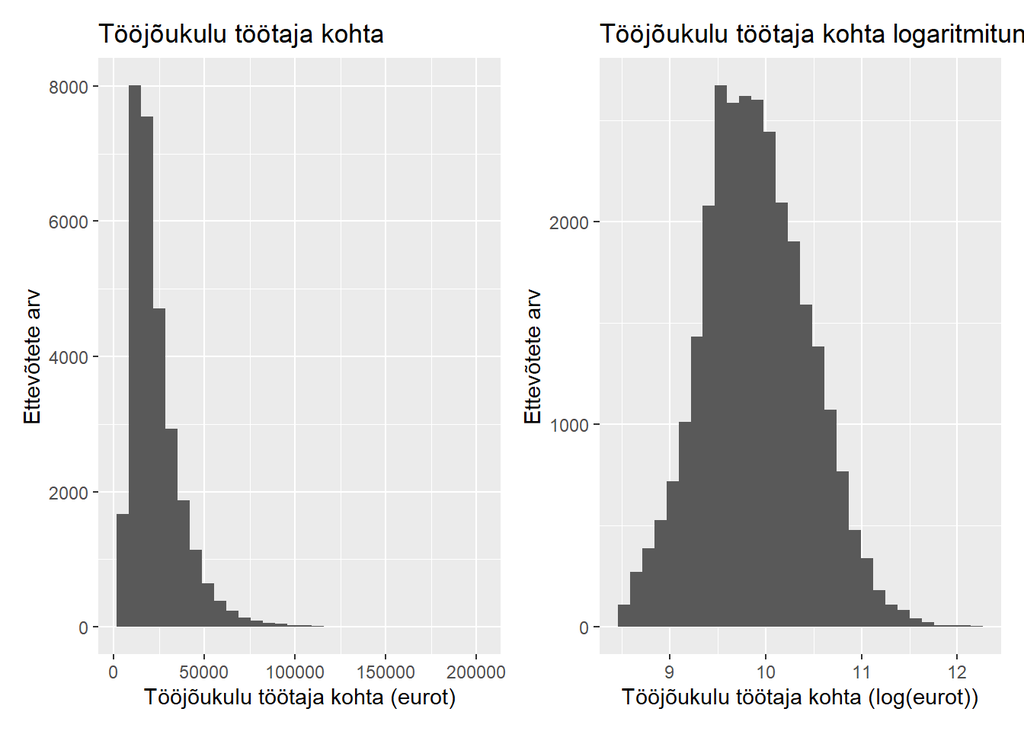

```r
library(patchwork)
p1 <- ggplot(andmed, aes(x = toojoukulu_tootaja)) +
  geom_histogram() +
  labs(
    title = "Tööjõukulu töötaja kohta",
    x = "Tööjõukulu töötaja kohta (eurot)",
    y = "Ettevõtete arv"
  )

p2 <- ggplot(andmed, aes(x = log_toojoukulu_tootaja)) +
  geom_histogram() +
  labs(
    title = "Tööjõukulu töötaja kohta logaritmituna",
    x = "Tööjõukulu töötaja kohta (log(eurot))",
    y = "Ettevõtete arv"
  )

p1 + p2
```

**#Vastus 5a:** Logaritmimine muudab jaotuse vähem paremale väljavenitatuks ning koondab väga suured väärtused väiksemasse vahemikku. Seetõttu muutub jaotus sümmeetrilisemaks ja selle üldist kuju on lihtsam võrrelda.

(b) Loo karpdiagramm (*boxplot*), kus on toodud `log_toojoukulu_tootaja` sektorite kaupa, kusjuures sektorid on mediaani alusel järjestatud (`reorder()`). Sektorinimed on pikad – pane sektorid vertikaalteljele (ggplot2 puhul `coord_flip()`, baasgraafika puhul `horizontal = TRUE`). Kirjutage lühidalt, mida joonisel näha on.

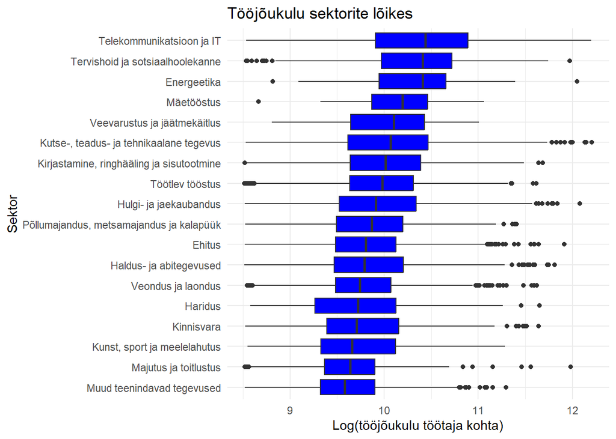

```r
andmed |>
  filter(!is.na(sektor)) |>
  ggplot(aes(x = reorder(sektor, log_toojoukulu_tootaja, median, na.rm = TRUE),
             y = log_toojoukulu_tootaja)) +
  geom_boxplot(fill = "blue") +
  coord_flip() +
  labs(title = "Tööjõukulu sektorite lõikes",
       x = "Sektor",
       y = "Log(tööjõukulu töötaja kohta)") +
  theme_minimal()
```

(c) Loo hajuvusdiagramm: `log_muugitulu_tootaja` horisontaalteljel, `log_toojoukulu_tootaja` vertikaalteljel. Punkte on ligi 30 000, seega kasuta läbipaistvust (`alpha`) või väikest punkti. Kirjeldage seost. Kas see on nii tugev, kui ootasite?

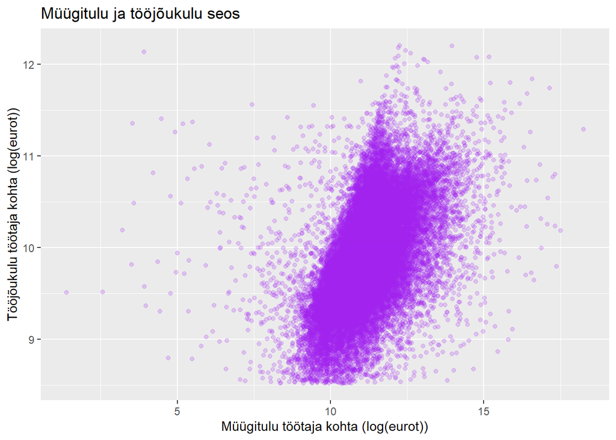

```r
ggplot(andmed, aes(
  x = log_muugitulu_tootaja,
  y = log_toojoukulu_tootaja
)) +
  geom_point(alpha = 0.2, color = "purple") +
  labs(
    title = "Müügitulu ja tööjõukulu seos",
    x = "Müügitulu töötaja kohta (log(eurot))",
    y = "Tööjõukulu töötaja kohta (log(eurot))"
  )
```

```r
cor(
  andmed$log_muugitulu_tootaja,
  andmed$log_toojoukulu_tootaja,
  use = "complete.obs"
)
```

```
[1] 0.5092399
```

**#Vastus 5c:** Seos on positiivne, suurema müügitulu korral on ka tööjõukulu töötaja kohta keskmiselt suurem. Punktipilv on siiski üsna lai, sest tööjõukulu sõltub lisaks müügitulule ka tegevusalast ja töömahukusest.

(d) Loo enda valikul üks joonis, mis näitab midagi, mida ülesannete 4 ja 5 tabelid ja joonised veel ei näita. Mida see joonis kirjeldab? Millisele küsimusele see vastab?

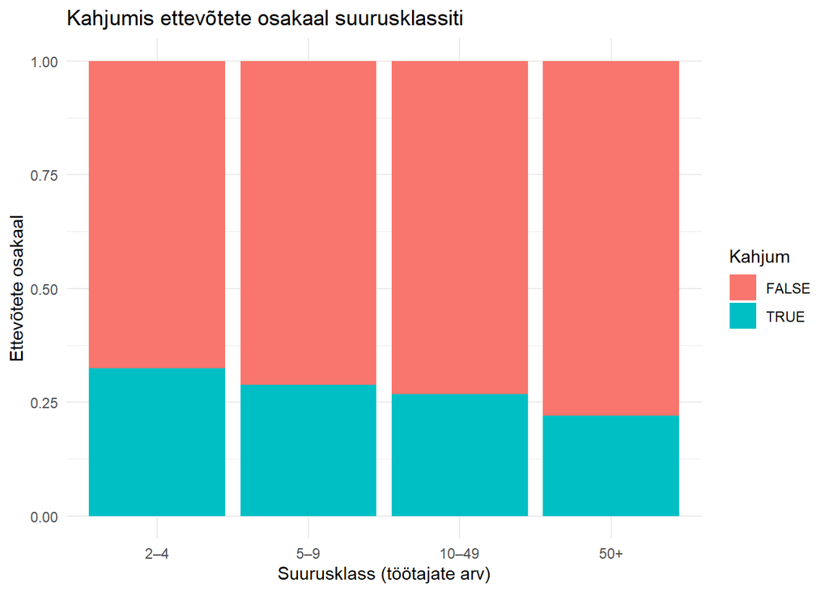

```r
ggplot(andmed, aes(x = suurusklass, fill = kahjum)) +
  geom_bar(position = "fill") +
  labs(title = "Kahjumis ettevõtete osakaal suurusklassiti",
       x = "Suurusklass (töötajate arv)",
       y = "Ettevõtete osakaal",
       fill = "Kahjum") +
  theme_minimal()
```

**#Vastus 5d:** Joonis näitab kahjumis olnud ettevõtete osakaalu erinevates suurusklassides. See vastab küsimusele: “Kas suuremad ettevõtted on harvemini kahjumis?” Selgelt on näha trendi, mis selgitab, mida suurem on ettevõte (töötajate arvu poolest), seda väiksem on tõenäosus, et aruaandeaasta lõpetatakse kahjumiga.